# Healthcare Claims Data Quality & Cohort Analysis Report

Medicare Synthetic Public Use Files Analysis

Plinth Analytics

December 03, 2025

# Executive Summary

## Overview

This report demonstrates a comprehensive data quality assessment and cohort analysis pipeline for Medicare claims data.

**Key Highlights:**

- **Automated Validation**: Data quality checks using the `pointblank` framework
- **Issue Detection**: Identified critical data quality issues in initial delivery
- **Remediation Tracking**: Before/after comparison showing issue resolution
- **Analysis Pipeline**: Complete workflow from raw data to survival analysis

## Key Metrics

**Data Volume Comparison**

Record counts across data deliveries

| Metric | Initial Delivery | Corrected Delivery |
| --- | --- | --- |
| Total Patients | 10,000 | 10,000 |
| Inpatient Claims | 5,662 | 5,477 |
| Prescription Records | 172,016 | 172,016 |
| Outpatient Claims | 69,267 | 69,267 |

# Data Quality Issues Detected

**Initial Data Delivery (v01)** underwent automated validation and **multiple critical issues were detected**. These findings triggered a data remediation request to the provider and an internal ETL code review.

## Patient Data Issues

Pointblank Validation

Patient Data - Issues Detected tibble Patients (Initial Delivery)

|  |  | STEP | COLUMNS | VALUES | TBL | EVAL | UNITS | PASS | FAIL | W | S | N | EXT |
| --- | --- | --- | --- | --- | --- | --- | --- | --- | --- | --- | --- | --- | --- |
|  | 1 | Key columns exist `col_exists()` | `▮desynpuf_id` | — |  | ✓ | `1` | `1` `1.00` | `0` `0.00` | — | — | — | — |
|  | 2 | Key columns exist `col_exists()` | `▮birth_dt` | — |  | ✓ | `1` | `1` `1.00` | `0` `0.00` | — | — | — | — |
|  | 3 | Key columns exist `col_exists()` | `▮death_dt` | — |  | ✓ | `1` | `1` `1.00` | `0` `0.00` | — | — | — | — |
|  | 4 | Key columns exist `col_exists()` | `▮sex_ident_cd` | — |  | ✓ | `1` | `1` `1.00` | `0` `0.00` | — | — | — | — |
|  | 5 | Key columns exist `col_exists()` | `▮race_cd` | — |  | ✓ | `1` | `1` `1.00` | `0` `0.00` | — | — | — | — |
|  | 6 | Key columns exist `col_exists()` | `▮cncr` | — |  | ✓ | `1` | `1` `1.00` | `0` `0.00` | — | — | — | — |
|  | 7 | Key columns exist `col_exists()` | `▮diabetes` | — |  | ✓ | `1` | `1` `1.00` | `0` `0.00` | — | — | — | — |
|  | 8 | Dataset has only One Row Per Patient (OORP) `rows_distinct()` | `▮desynpuf_id` | — |  | ✓ | `10K` | `10K` `1.00` | `0` `0.00` | — | — | — | — |
|  | 9 | Everyone born after 01-01-1900 `col_vals_gt()` | `▮birth_dt` | `1900-01-01` |  | ✓ | `10K` | `10K` `0.99` | `20` `0.01` | — | — | — |  |
|  | 10 | Everyone born after 01-01-1900 `col_vals_gt()` | `▮death_dt` | `1900-01-01` |  | ✓ | `10K` | `10K` `1.00` | `0` `0.00` | — | — | — | — |
|  | 11 | Dataset contains alive and dead patients `col_vals_make_set()` | `▮death_observed` | `TRUE, FALSE` |  | ✓ | `3` | `2` `0.67` | `1` `0.33` | — | — | — |  |
|  | 12 | Dataset contains both Male and Female patients `col_vals_make_set()` | `▮sex_ident_cd` | `Male, Female` |  | ✓ | `3` | `2` `0.67` | `1` `0.33` | — | — | — |  |
|  | 13 | Dataset contains patients with and without cancer `col_vals_make_set()` | `▮cncr` | `TRUE, FALSE` |  | ✓ | `3` | `2` `0.67` | `1` `0.33` | — | — | — |  |

2025-12-03 13:24:34 CST < 1 s 2025-12-03 13:24:34 CST

### Issues Identified:

**Patient Data Issues Summary**

[output not shown]

## Inpatient Claims Issues

Pointblank Validation

Inpatient Data - Issues Detected tibble Inpatient Claims (Initial Delivery)

|  |  | STEP | COLUMNS | VALUES | TBL | EVAL | UNITS | PASS | FAIL | W | S | N | EXT |
| --- | --- | --- | --- | --- | --- | --- | --- | --- | --- | --- | --- | --- | --- |
|  | 1 | Key columns exist `col_exists()` | `▮desynpuf_id` | — |  | ✓ | `1` | `1` `1.00` | `0` `0.00` | — | — | — | — |
|  | 2 | Claim admin is a date `col_is_date()` | `▮clm_from_dt` | — |  | ✓ | `1` | `1` `1.00` | `0` `0.00` | — | — | — | — |
|  | 3 | Claim admin is a date `col_is_date()` | `▮clm_thru_dt` | — |  | ✓ | `1` | `1` `1.00` | `0` `0.00` | — | — | — | — |
|  | 4 | Claim payment amount is positive `col_vals_gte()` | `▮clm_pmt_amt` | `0` |  | ✓ | `6K` | `6K` `0.98` | `104` `0.02` | — | — | — |  |

2025-12-03 13:24:35 CST < 1 s 2025-12-03 13:24:35 CST

### Negative Payment Investigation

**Sample of Negative Payment Claims**

104 records with negative payments detected

| desynpuf_id | clm_id | clm_from_dt | clm_pmt_amt |
| --- | --- | --- | --- |
| 012CE260F81EE263 | 1.969712e+14 | 2008-08-15 | −$27,489.00 |
| 03F2AC0D5EEB4C41 | 1.960512e+14 | 2009-12-31 | −$13,509.00 |
| 05DF8BAC65670664 | 1.967612e+14 | 2009-03-14 | −$25,972.00 |
| 09218869402EA6AE | 1.967712e+14 | 2009-04-28 | −$26,537.00 |
| 0DCEE588ECFD4EDC | 1.966012e+14 | 2010-07-22 | −$24,294.00 |
| 0F978C9C89664109 | 1.960612e+14 | 2010-08-09 | −$19,685.00 |
| 14BA88C07EC6EA2F | 1.963112e+14 | 2009-03-22 | −$19,112.00 |
| 19377875C7108AC1 | 1.962012e+14 | 2009-03-08 | −$17,211.00 |
| 1E54FB03870450D2 | 1.966312e+14 | 2009-01-23 | −$300.00 |
| 1FE130756B42C7F2 | 1.965612e+14 | 2010-03-15 | −$300.00 |

# Data Quality After Remediation

**Corrected Data Delivery (v02)** with updated ETL pipeline (v02) was validated. **All critical issues have been resolved.**

## Patient Data - Resolved

Pointblank Validation

Patient Data - All Issues Resolved tibble Patients (Corrected Delivery)

|  |  | STEP | COLUMNS | VALUES | TBL | EVAL | UNITS | PASS | FAIL | W | S | N | EXT |
| --- | --- | --- | --- | --- | --- | --- | --- | --- | --- | --- | --- | --- | --- |
|  | 1 | Key columns exist `col_exists()` | `▮desynpuf_id` | — |  | ✓ | `1` | `1` `1.00` | `0` `0.00` | — | — | — | — |
|  | 2 | Key columns exist `col_exists()` | `▮birth_dt` | — |  | ✓ | `1` | `1` `1.00` | `0` `0.00` | — | — | — | — |
|  | 3 | Key columns exist `col_exists()` | `▮death_dt` | — |  | ✓ | `1` | `1` `1.00` | `0` `0.00` | — | — | — | — |
|  | 4 | Key columns exist `col_exists()` | `▮sex_ident_cd` | — |  | ✓ | `1` | `1` `1.00` | `0` `0.00` | — | — | — | — |
|  | 5 | Key columns exist `col_exists()` | `▮race_cd` | — |  | ✓ | `1` | `1` `1.00` | `0` `0.00` | — | — | — | — |
|  | 6 | Key columns exist `col_exists()` | `▮cncr` | — |  | ✓ | `1` | `1` `1.00` | `0` `0.00` | — | — | — | — |
|  | 7 | Key columns exist `col_exists()` | `▮diabetes` | — |  | ✓ | `1` | `1` `1.00` | `0` `0.00` | — | — | — | — |
|  | 8 | Dataset has only One Row Per Patient (OORP) `rows_distinct()` | `▮desynpuf_id` | — |  | ✓ | `10K` | `10K` `1.00` | `0` `0.00` | — | — | — | — |
|  | 9 | Everyone born after 01-01-1900 `col_vals_gt()` | `▮birth_dt` | `1900-01-01` |  | ✓ | `10K` | `10K` `1.00` | `0` `0.00` | — | — | — | — |
|  | 10 | Everyone born after 01-01-1900 `col_vals_gt()` | `▮death_dt` | `1900-01-01` |  | ✓ | `10K` | `10K` `1.00` | `0` `0.00` | — | — | — | — |
|  | 11 | Dataset contains alive and dead patients `col_vals_make_set()` | `▮death_observed` | `TRUE, FALSE` |  | ✓ | `3` | `3` `1.00` | `0` `0.00` | — | — | — | — |
|  | 12 | Dataset contains both Male and Female patients `col_vals_make_set()` | `▮sex_ident_cd` | `Male, Female` |  | ✓ | `3` | `3` `1.00` | `0` `0.00` | — | — | — | — |
|  | 13 | Dataset contains patients with and without cancer `col_vals_make_set()` | `▮cncr` | `TRUE, FALSE` |  | ✓ | `3` | `3` `1.00` | `0` `0.00` | — | — | — | — |

2025-12-03 13:24:35 CST < 1 s 2025-12-03 13:24:36 CST

## Inpatient Claims - Resolved

Pointblank Validation

Inpatient Data - All Issues Resolved tibble Inpatient Claims (Corrected Delivery)

|  |  | STEP | COLUMNS | VALUES | TBL | EVAL | UNITS | PASS | FAIL | W | S | N | EXT |
| --- | --- | --- | --- | --- | --- | --- | --- | --- | --- | --- | --- | --- | --- |
|  | 1 | Key columns exist `col_exists()` | `▮desynpuf_id` | — |  | ✓ | `1` | `1` `1.00` | `0` `0.00` | — | — | — | — |
|  | 2 | Claim admin is a date `col_is_date()` | `▮clm_from_dt` | — |  | ✓ | `1` | `1` `1.00` | `0` `0.00` | — | — | — | — |
|  | 3 | Claim admin is a date `col_is_date()` | `▮clm_thru_dt` | — |  | ✓ | `1` | `1` `1.00` | `0` `0.00` | — | — | — | — |
|  | 4 | Claim payment amount is positive `col_vals_gte()` | `▮clm_pmt_amt` | `0` |  | ✓ | `5K` | `5K` `1.00` | `0` `0.00` | — | — | — | — |

2025-12-03 13:24:36 CST < 1 s 2025-12-03 13:24:36 CST

## ORPP Derived Table

Pointblank Validation

Derived ORPP Table Validation tibble One Row Per Patient

[output not shown]

2025-12-03 13:24:36 CST < 1 s 2025-12-03 13:24:36 CST

## Validation Comparison

**Before vs After: Validation Results**

Comparison of data quality across deliveries

| Table | Version | Total Tests | Tests Passed | Pass Rate | Status |
| --- | --- | --- | --- | --- | --- |
| Patient Demographics |  |  |  |  |  |
| Patients | Initial (v01) | 13 | 9 | 69.2% | FAIL |
| Patients | Corrected (v02) | 13 | 13 | 100.0% | PASS |
| Inpatient Claims |  |  |  |  |  |
| Inpatient | Initial (v01) | 4 | 3 | 75.0% | FAIL |
| Inpatient | Corrected (v02) | 4 | 4 | 100.0% | PASS |

# Patient Demographics

## Population Overview

**Patient Population Characteristics**

N = 10,000 patients

| **Characteristic** | **N = 10,000**<sup>1</sup> |
| --- | --- |
| Sex |  |
| Female | 5,543 (55%) |
| Male | 4,457 (45%) |
| Race/Ethnicity |  |
| Black | 1,028 (10%) |
| Hispanic | 235 (2.4%) |
| Other | 442 (4.4%) |
| White | 8,295 (83%) |
| Diabetes | 3,845 (38%) |
| Cancer History | 633 (6.3%) |
| End-Stage Renal Disease |  |
| 0 | 9,297 (93%) |
| Y | 703 (7.0%) |
| Deceased | 7,349 (73%) |

<sup>1</sup> n (%)

## Sex Distribution Comparison

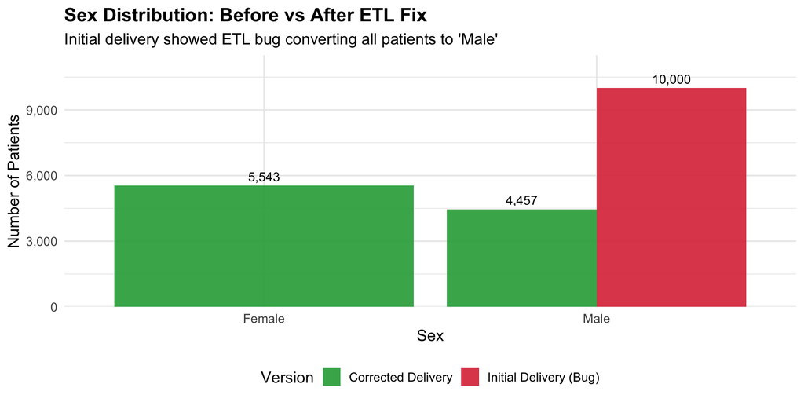

## Race/Ethnicity

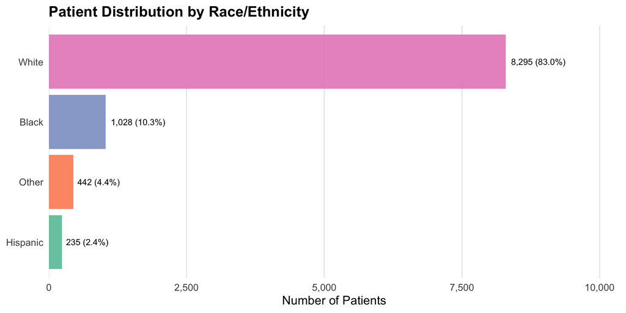

# Cohort Definition & Attrition

## Inclusion Criteria

**Cohort Inclusion Criteria**

| Step | Criterion | Rationale |
| --- | --- | --- |
| 1 | Race is White or Black | Focus on populations with sufficient sample size |
| 2 | Has Diabetes diagnosis | Target population of clinical interest |
| 3 | Sex is Male | Subset for focused analysis |
| 4 | Median inpatient payment >= $10,000 | Patients with significant healthcare utilization |
| 5 | Median prescription cost > $20 | Patients with ongoing medication needs |
| 6 | At least 18 years of known survival | Adequate follow-up for survival analysis |

## Attrition Analysis

**Cohort Attrition Summary**

Sequential application of inclusion criteria

| Criterion | Patients Remaining | Patients Excluded | Retention Rate |
| --- | --- | --- | --- |
| Everyone | 10,000 | - | 100.0% |
| Race is White or Black | 9,323 | -677 | 93.2% |
| Has Diabetes | 3,605 | -5,718 | 36.0% |
| Sex is Male | 1,526 | -2,079 | 15.3% |
| Median inpatient payment >= $10,000 | 268 | -1,258 | 2.7% |
| Median prescription cost > $20 | 83 | -185 | 0.8% |
| 18+ years of known survival | 83 | 0 | 0.8% |

## Attrition Visualization

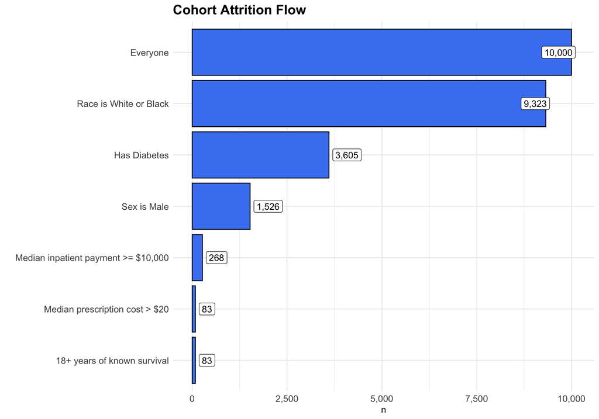

# Final Cohort Analysis

## Cohort Characteristics

**Final Cohort Characteristics by Race**

N = 83 patients meeting all inclusion criteria

| **Variable** | **Overall** N = 83<sup>1</sup> | **Black** N = 7<sup>1</sup> | **White** N = 76<sup>1</sup> |
| --- | --- | --- | --- |
| Survival Time (years) | 52.1 (43.6, 63.6) | 39.7 (26.4, 50.1) | 52.7 (43.9, 63.8) |
| Death Observed | 61 (73%) | 5 (71%) | 56 (74%) |
| Median Inpatient Payment ($) | 14,000.0 (11,000.0, 20,000.0) | 14,000.0 (10,000.0, 22,500.0) | 14,000.0 (11,250.0, 19,500.0) |
| Median Rx Cost ($) | 40.0 (30.0, 55.0) | 40.0 (30.0, 50.0) | 40.0 (30.0, 57.5) |
| Number of Inpatient Claims |  |  |  |
| 1 | 53 (64%) | 4 (57%) | 49 (64%) |
| 2 | 19 (23%) | 2 (29%) | 17 (22%) |
| 3 | 6 (7.2%) | 0 (0%) | 6 (7.9%) |
| 4 | 3 (3.6%) | 0 (0%) | 3 (3.9%) |
| 6 | 1 (1.2%) | 0 (0%) | 1 (1.3%) |
| 9 | 1 (1.2%) | 1 (14%) | 0 (0%) |
| Number of Prescriptions | 32.0 (10.0, 50.0) | 45.0 (17.0, 48.0) | 31.0 (9.0, 50.0) |

<sup>1</sup> Median (Q1, Q3); n (%)

## Survival Analysis

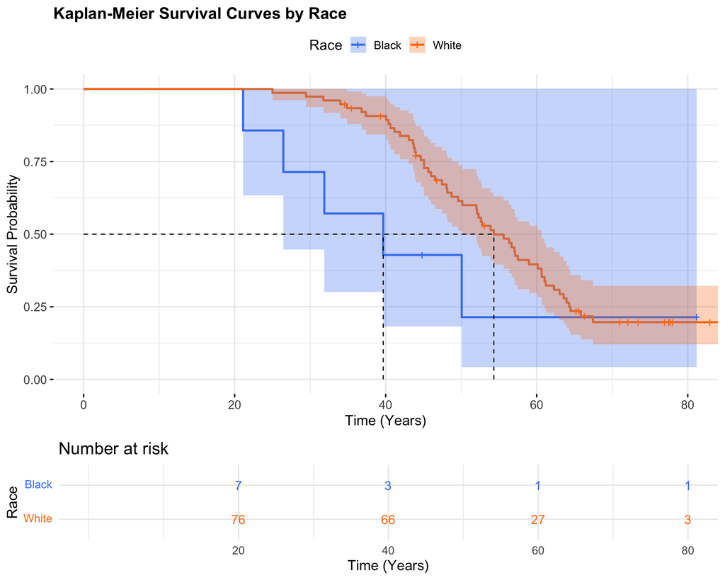

## Healthcare Utilization

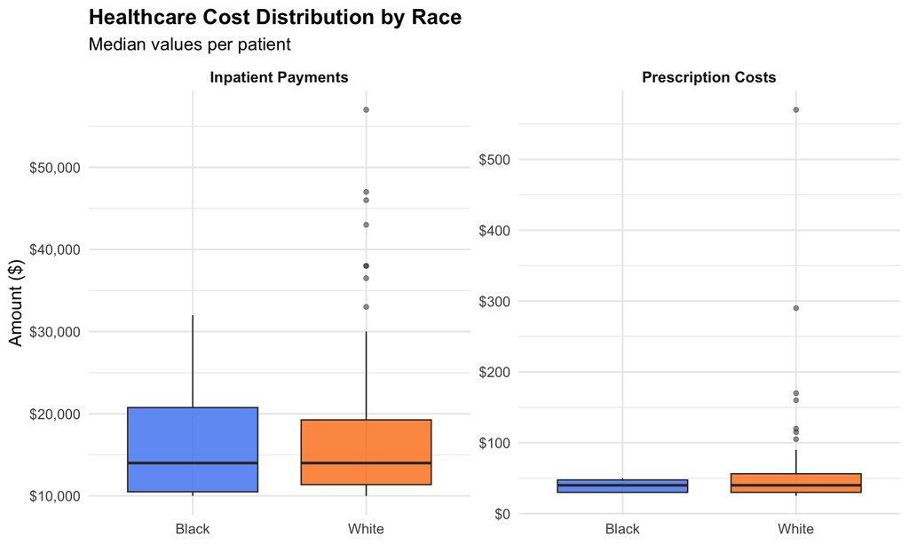

# Summary & Recommendations

## Data Quality Findings

| Category | Initial Status | Final Status |
| --- | --- | --- |
| Patient Demographics | **4 Critical Issues** | All Resolved |
| Inpatient Claims | **104 Invalid Records** | All Resolved |
| ORPP Derived Data | N/A | All Validations Pass |

## Key Actions Taken

1. **Data Provider Notification**: Reported birth date anomalies, missing cancer/death indicators
2. **Internal ETL Fix**: Corrected sex mapping bug in `etl_patients_01()`
3. **Re-delivery Request**: Obtained corrected data delivery (v02)
4. **Validation Confirmation**: All automated checks now pass

## Recommendations

- Continue automated validation on all future data deliveries
- Implement real-time alerting for critical validation failures
- Expand validation rules to cover additional data quality dimensions

# Appendix

## Data Pipeline

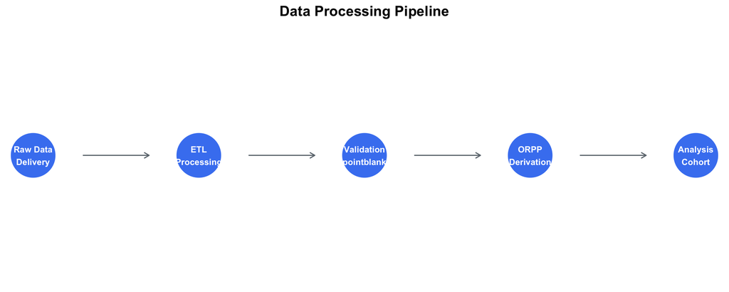

Report generated by **Plinth Analytics** | 2025-12-03 13:24:39 CST

Data validation powered by [pointblank](https://rich-iannone.github.io/pointblank/)